# Background & Context

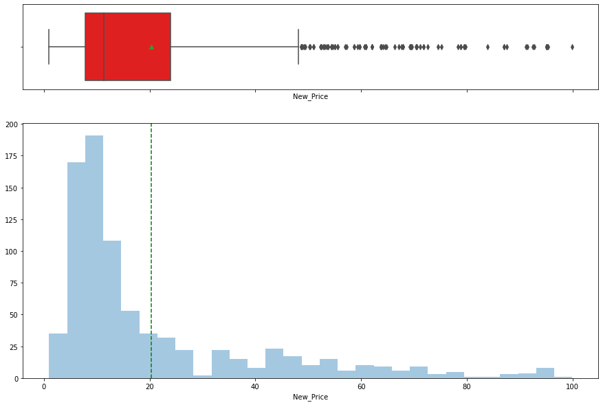

```python
hist_box(df.New_Price)
```

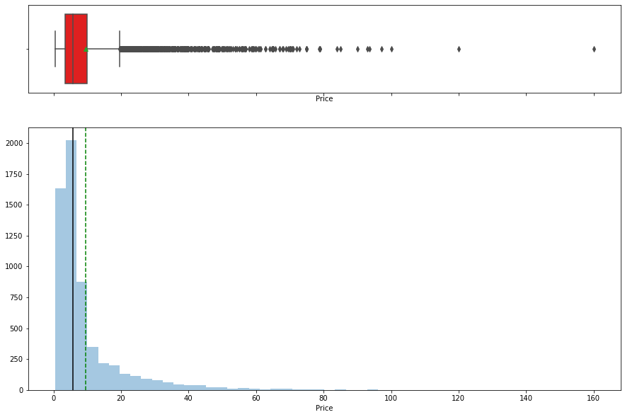

```python
#Highly skewed to the right.  Lots of outliers, and, given the
#large number of missing values, I can't see a reason to keep this data so far.
hist_box(df.Price)
```

```python
#The target variable is right skewed with lots of high outliers - to be expected.
#We would expect to see some high prices, enough to pull the mean beyond the median
#MISSING VALUE TREATMENT
#I will use median for 'Engine' and 'Power', which are both right-skewed, and
#mean for 'Mileage', which is not skewed
#Even though it is not skewed, I will use median for 'Seats' since it is
#nonsensical to have a decimal number of seats
df['Mileage'].fillna(df['Mileage'].mean(), inplace=True)
df['Power'].fillna(df['Power'].median(), inplace=True)
df['Engine'].fillna(df['Engine'].median(), inplace=True)
df['Seats'].fillna(df['Seats'].median(), inplace=True)
df.info()
```

```
<class 'pandas.core.frame.DataFrame'>
Int64Index: 6019 entries, 0 to 6018
Data columns (total 13 columns):
 #   Column             Non-Null Count  Dtype
---  ------             --------------  -----
 0   Name               6019 non-null   category
 1   Location           6019 non-null   category
 2   Year               6019 non-null   int64
 3   Kilometers_Driven  6019 non-null   int64
 4   Fuel_Type          6019 non-null   category
 5   Transmission       6019 non-null   category
 6   Owner_Type         6019 non-null   category
 7   Mileage            6019 non-null   float64
 8   Engine             6019 non-null   float64
 9   Power              6019 non-null   float64
 10  Seats              6019 non-null   float64
 11  New_Price          824 non-null    float64
 12  Price              6019 non-null   float64
dtypes: category(5), float64(6), int64(2)
memory usage: 555.3 KB
```

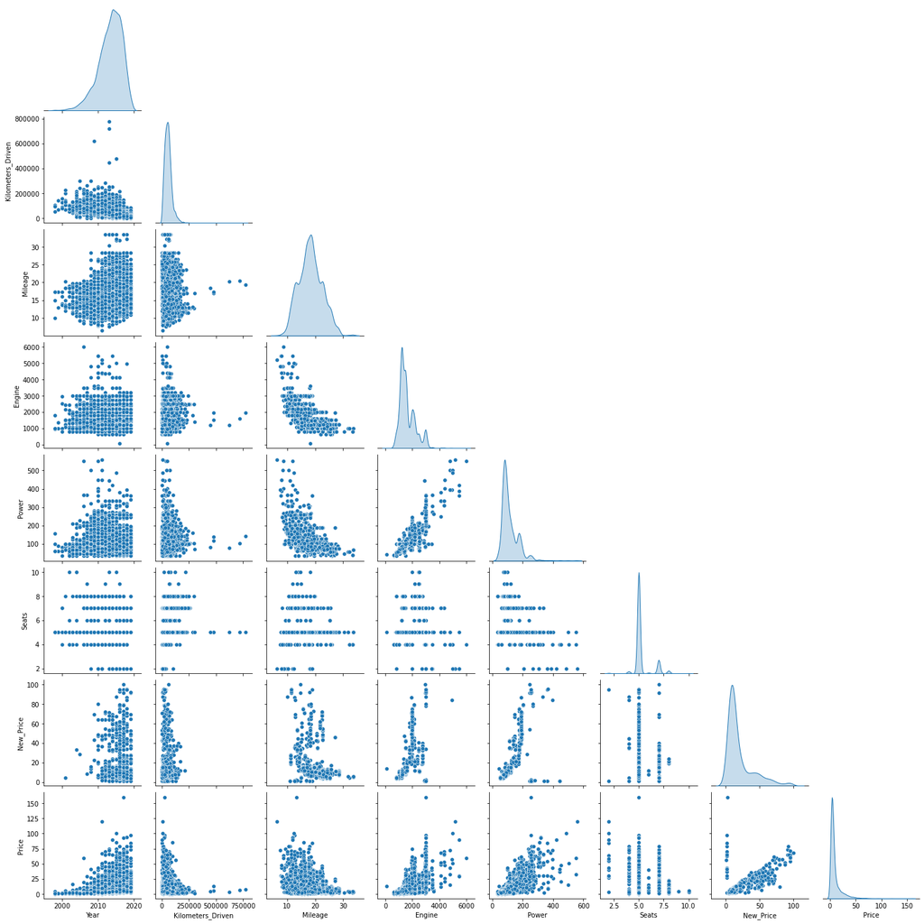

```python
#Running pairplot to see correlations, and also to get an idea if New_Price
#is even worth trying to keep
sns.pairplot(df, corner=True, diag_kind = 'kde')
```

New Price, as should probably be expected, has a strong correlation with price. However, given the fact that we are missing so many values, coupled with the fact that new car prices vary significantly, I don't think it would be appropriate to replace this variable with the mean, median, or any other measure of central tendency. If we simply drop all rows that are missing new price, I feel like we lose more than we gain. Therefore, I will drop this variable. Future research should include getting this data from sources like Kelley Blue Book, and including it in a future regression.